# Analysis of stormdata and its impact on health and economy

Carl Ebbinghaus

17 12 2017

## Synopsis

In this short report you’ll find an analysis of the stormdata given in the Reproducible Research course. The event types (EVTYPE) with the highest impact on health (ie INJURIES and FATALITIES) will be shown as well as the event types with the highest on economic consequences (ie PROPDMG and CROPDMG).

## Data processing

At first we’ll download the given file into our working directory and then we’ll read it.

```r
fileUrl <- "https://d396qusza40orc.cloudfront.net/repdata%2Fdata%2FStormData.csv.bz2"
download.file(fileUrl, destfile = "./RepResStormData.csv.bz2")
stormdata <- read.csv("RepResStormData.csv.bz2")
# str(stormdata) # not necessary for the report but you might want to have a look at the data structure
```

#### Across the United States, which types of events (as indicated in the EVTYPE variable) are most harmful with respect to population health?

After looking at the documentation of the dataset I came to the conclusion that INJURIES and FATALITIES are the two variables that are worth looking at most - with regards to the question of impact on population health. For INJURIES and FATALITIES I’m going to aggregate and sum up by EVTYPE. By ordering those in decreasing order, I’ll get two data sets that have the event types with the highest number of injuries (or fatalities) at the top. We will plot these in the RESULTS section, in order to see which event types have the biggest impact.

```r
evt.injuries <- aggregate(INJURIES ~ EVTYPE, stormdata, sum)
evt.injuries <- evt.injuries[order(evt.injuries$INJURIES, decreasing = TRUE),]

evt.fatalities <- aggregate(FATALITIES ~ EVTYPE, stormdata, sum)
evt.fatalities <- evt.fatalities[order(evt.fatalities$FATALITIES, decreasing = TRUE),]
```

After aggregation and ordering we can join both data sets to be able to print injuries and fatalities in one table. Apart from that we will also look at the top 15 single events with the highest numbers of injuries and fatalities. That’s why we save an individual copy of the stormdata ordered by injuries and fatalities.

```r
evt.injuries.top15 <- head(evt.injuries, 15)
evt.fatalities.top15 <- head(evt.fatalities, 15)

library(dplyr)
evt.injfat <- full_join(evt.fatalities.top15, evt.injuries.top15, by="EVTYPE")
```

Apart from that we will also look at the top 15 single events with the highest numbers of injuries and fatalities. That’s why we save an individual copy of the stormdata ordered by injuries and fatalities.

```r
stormdata.sortbyfatal <- stormdata[order(stormdata$FATALITIES, decreasing=TRUE),]
stormdata.sortbyinj <- stormdata[order(stormdata$INJURIES, decreasing=TRUE),]
```

#### Across the United States, which types of events have the greatest economic consequences?

For the economic consequences looking at PROPDMG and CROPDMG looked most promising to me. Hence I’ll do pretty much the same steps as for INJURIES and FATALITIES:

```r
evt.propdmg <- aggregate(PROPDMG ~ EVTYPE, stormdata, sum)
evt.propdmg <- evt.propdmg[order(evt.propdmg$PROPDMG, decreasing = TRUE),]

evt.cropdmg <- aggregate(CROPDMG ~ EVTYPE, stormdata, sum)
evt.cropdmg <- evt.cropdmg[order(evt.cropdmg$CROPDMG, decreasing = TRUE),]

evt.propdmg.top15 <- head(evt.propdmg, 15)
evt.cropdmg.top15 <- head(evt.cropdmg, 15)

library(dplyr)
evt.propdcropd <- full_join(evt.propdmg.top15, evt.cropdmg.top15, by="EVTYPE")

stormdata.sortbycropd <- stormdata[order(stormdata$CROPDMG, decreasing=TRUE),]
stormdata.sortbypropd <- stormdata[order(stormdata$PROPDMG, decreasing=TRUE),]
```

## Results

### Injuries and fatalities - impact on health

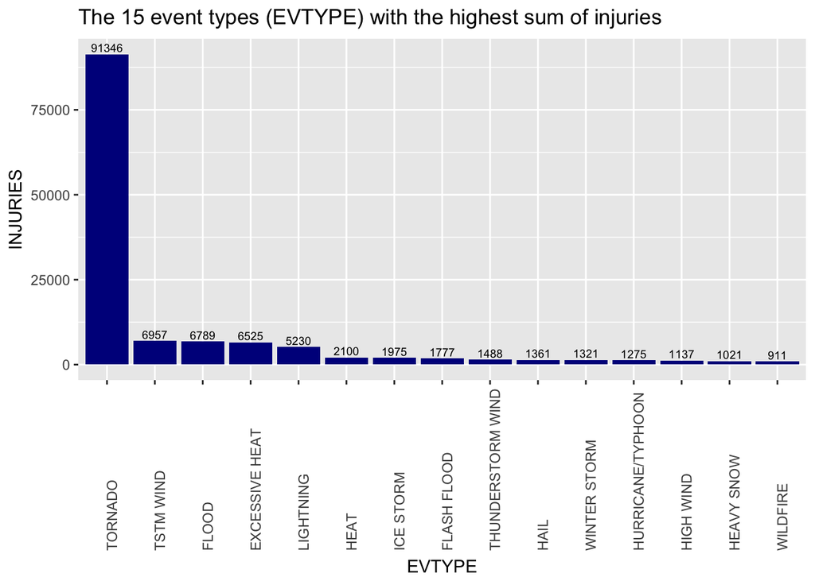

```r
library(ggplot2)

ggplot(aes(x=EVTYPE, y=INJURIES), data = evt.injuries.top15) + geom_bar(fill="dark blue", stat = "identity") + scale_x_discrete(limits=evt.injuries.top15$EVTYPE) + theme(axis.text.x = element_text(angle=90, hjust=0)) + ggtitle("The 15 event types (EVTYPE) with the highest sum of injuries") + geom_text(aes(label=INJURIES), vjust=-0.3, color="black", size=2.5)
```

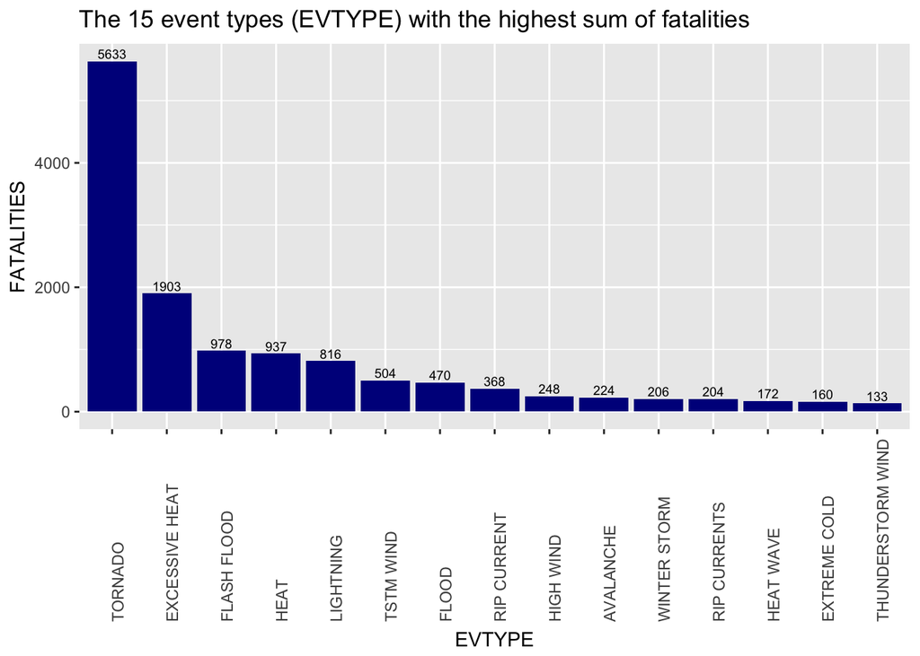

```r
ggplot(aes(x=EVTYPE, y=FATALITIES), data = evt.fatalities.top15) + geom_bar(fill="dark blue", stat = "identity") + scale_x_discrete(limits=evt.fatalities.top15$EVTYPE) + theme(axis.text.x = element_text(angle=90, hjust=0)) + ggtitle("The 15 event types (EVTYPE) with the highest sum of fatalities") + geom_text(aes(label=FATALITIES), vjust=-0.3, color="black", size=2.5)
```

```r
evt.injfat
```

```
##               EVTYPE FATALITIES INJURIES
## 1            TORNADO       5633    91346
## 2     EXCESSIVE HEAT       1903     6525
## 3        FLASH FLOOD        978     1777
## 4               HEAT        937     2100
## 5          LIGHTNING        816     5230
## 6          TSTM WIND        504     6957
## 7              FLOOD        470     6789
## 8        RIP CURRENT        368       NA
## 9          HIGH WIND        248     1137
## 10         AVALANCHE        224       NA
## 11      WINTER STORM        206     1321
## 12      RIP CURRENTS        204       NA
## 13         HEAT WAVE        172       NA
## 14      EXTREME COLD        160       NA
## 15 THUNDERSTORM WIND        133     1488
## 16         ICE STORM         NA     1975
## 17              HAIL         NA     1361
## 18 HURRICANE/TYPHOON         NA     1275
## 19        HEAVY SNOW         NA     1021
## 20          WILDFIRE         NA      911
```

As visible in the plots as well as in the printed data set the event type TORNADO has the highest number of fatalities and injuries.

#### Single events and there event type with the highest number of fatalities and injuries:

These are the single events with the highest numbers of fatalities and injuries. This might also be an indicator of which event types are escpecially dangerous - even if the sum of the individual event type isn’t the highest.

```r
head(stormdata.sortbyfatal[, c("EVTYPE","FATALITIES")], 15)
```

```
##                EVTYPE FATALITIES
## 198704           HEAT        583
## 862634        TORNADO        158
## 68670         TORNADO        116
## 148852        TORNADO        114
## 355128 EXCESSIVE HEAT         99
## 67884         TORNADO         90
## 46309         TORNADO         75
## 371112 EXCESSIVE HEAT         74
## 230927 EXCESSIVE HEAT         67
## 78567         TORNADO         57
## 247938   EXTREME HEAT         57
## 6370          TORNADO         50
## 598500 EXCESSIVE HEAT         49
## 606363 EXCESSIVE HEAT         46
## 860386        TORNADO         44
```

```r
head(stormdata.sortbyinj[, c("EVTYPE","INJURIES")], 15)
```

```
##                   EVTYPE INJURIES
## 157885           TORNADO     1700
## 223449         ICE STORM     1568
## 67884            TORNADO     1228
## 116011           TORNADO     1150
## 862634           TORNADO     1150
## 344159             FLOOD      800
## 860386           TORNADO      800
## 68670            TORNADO      785
## 529351 HURRICANE/TYPHOON      780
## 344178             FLOOD      750
## 858228           TORNADO      700
## 344158             FLOOD      600
## 148852           TORNADO      597
## 35124            TORNADO      560
## 344163             FLOOD      550
```

### Property and crop damage - economic impact

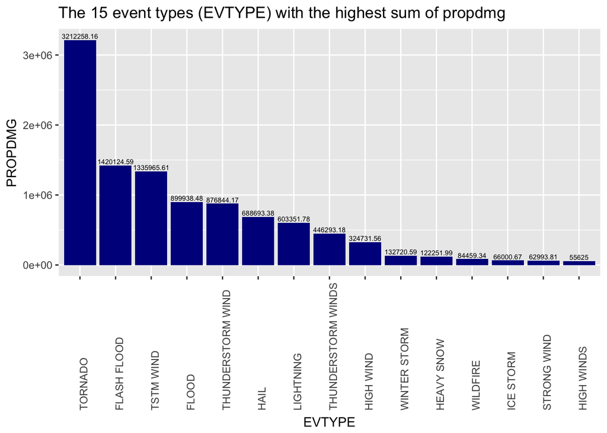

```r
library(ggplot2)

ggplot(aes(x=EVTYPE, y=PROPDMG), data = evt.propdmg.top15) + geom_bar(fill="dark blue", stat = "identity") + scale_x_discrete(limits=evt.propdmg.top15$EVTYPE) + theme(axis.text.x = element_text(angle=90, hjust=0)) + ggtitle("The 15 event types (EVTYPE) with the highest sum of propdmg") + geom_text(aes(label=PROPDMG), vjust=-0.3, color="black", size=2)
```

We will not plot crop damage as it doesn’t have as high an impact as property damage. We will include the 15 event types with the highest crop damage in the printed table though:

```r
evt.propdcropd
```

```
##                EVTYPE    PROPDMG   CROPDMG
## 1             TORNADO 3212258.16 100018.52
## 2         FLASH FLOOD 1420124.59 179200.46
## 3           TSTM WIND 1335965.61 109202.60
## 4               FLOOD  899938.48 168037.88
## 5   THUNDERSTORM WIND  876844.17  66791.45
## 6                HAIL  688693.38 579596.28
## 7           LIGHTNING  603351.78        NA
## 8  THUNDERSTORM WINDS  446293.18  18684.93
## 9           HIGH WIND  324731.56  17283.21
## 10       WINTER STORM  132720.59        NA
## 11         HEAVY SNOW  122251.99        NA
## 12           WILDFIRE   84459.34        NA
## 13          ICE STORM   66000.67        NA
## 14        STRONG WIND   62993.81        NA
## 15         HIGH WINDS   55625.00        NA
## 16            DROUGHT         NA  33898.62
## 17         HEAVY RAIN         NA  11122.80
## 18       FROST/FREEZE         NA   7034.14
## 19       EXTREME COLD         NA   6121.14
## 20     TROPICAL STORM         NA   5899.12
## 21          HURRICANE         NA   5339.31
## 22     FLASH FLOODING         NA   5126.05
```

As visible in the plot the event type TORNADO has the highest property damage. The highest crop damage comes from HAIL as visible in the table.

#### Single events and there event type with the highest number of property and crop damage:

These are the single events with the highest numbers of property and crop damage. This might also be an indicator of which event types are escpecially expensive for the economy - even if the sum of the individual event type isn’t the highest.

```r
head(stormdata.sortbycropd[, c("EVTYPE","CROPDMG")], 15)
```

```
##                EVTYPE CROPDMG
## 544253        DROUGHT     990
## 631126 TROPICAL STORM     985
## 322172          FLOOD     978
## 387863          FLOOD     975
## 279930 River Flooding     950
## 743347    FLASH FLOOD     950
## 548558          FLOOD     920
## 267899      HIGH WIND     900
## 279270    FLASH FLOOD     900
## 280333        TORNADO     900
## 288365     HEAVY SNOW     900
## 306732           HAIL     900
## 337760 TSTM WIND/HAIL     900
## 356425          FLOOD     900
## 377343          FLOOD     900
```

```r
head(stormdata.sortbypropd[, c("EVTYPE","PROPDMG")], 15)
```

```
##                   EVTYPE PROPDMG
## 778568 THUNDERSTORM WIND    5000
## 808182       FLASH FLOOD    5000
## 808183       FLASH FLOOD    5000
## 900685        WATERSPOUT    5000
## 791403         LANDSLIDE    4800
## 750967           TORNADO    4410
## 762429 THUNDERSTORM WIND    3500
## 815064 THUNDERSTORM WIND    3200
## 749050         HIGH WIND    3000
## 755020             FLOOD    3000
## 881000       FLASH FLOOD    3000
## 848601         LANDSLIDE    1584
## 789445     COASTAL FLOOD    1000
## 811973         LIGHTNING    1000
## 815187           TORNADO    1000
```

### Summary

In this report stormdata was analyzed with regards to impact on health and economic factors. As indicated in the documentation of the stormdata in some cases, such as with Hurricane Katrina, it may be nearly impossible to determine what event (i.e., Storm Surge/Tide, Hurricane, Flash Flood, or High Surf) resulted in a directly-related death. For these situations, in order to simplify the Storm Data preparation process, it is appropriate to assign the death to the Hurricane (Typhoon) event.